# Statistics for Bioengineering - Week 2

# Common Probability Distributions

## A Bernouli Trial

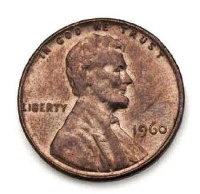

## Probability of Independent Events

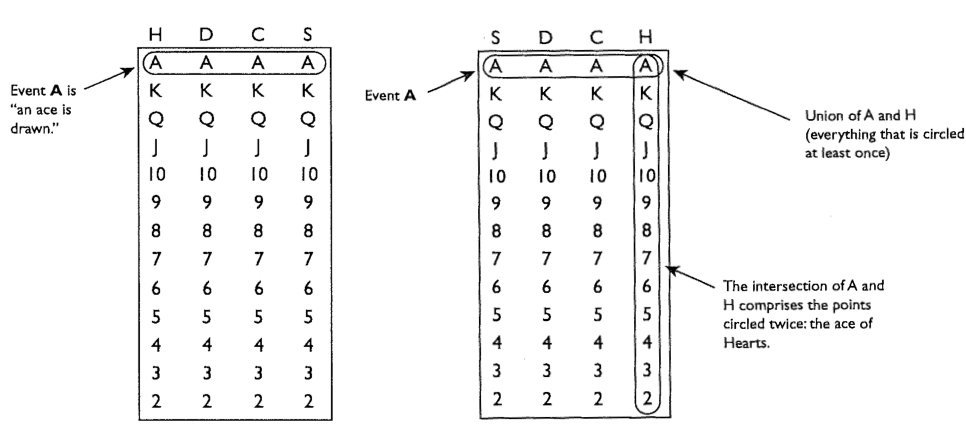

Source: Whitlock & Schluter, *The Analysis of Biological Data*

## Bernoulli Distribution

Describes the expected outcome of a single event with probability $p$.

**Example: Flipping a fair coin once**

$$Pr(X=\text{Head}) = \frac{1}{2} = 0.5 = p$$

$$Pr(X=\text{Tails}) = \frac{1}{2} = 0.5 = 1 - p = q$$

Probabilities always sum to 1: $p + q = 1$

## Let’s Simulate Coin Flips

- Output
- Code
- Interpretation

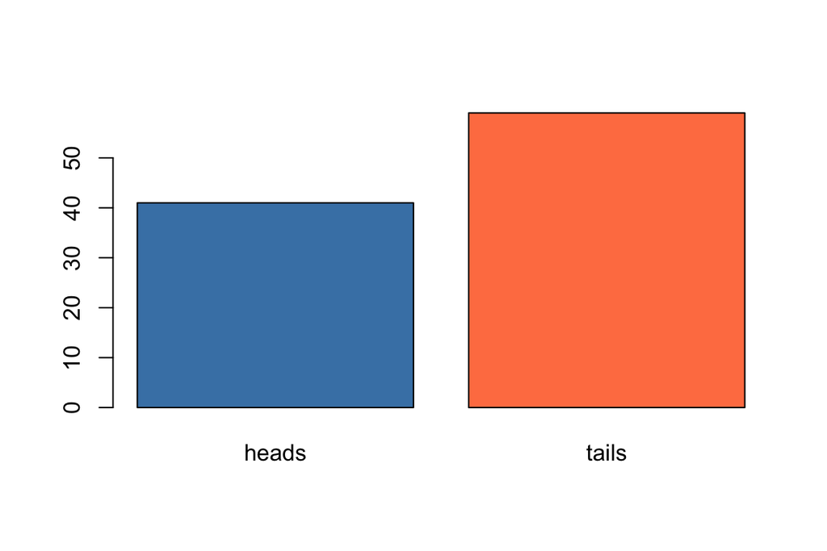

```r
coin <- c("heads", "tails")
flips <- sample(coin, prob = c(0.5, 0.5), size = 100, replace = TRUE)
barplot(table(flips), col = c("steelblue", "coral"))
```

- The `sample()` function simulates 100 fair coin flips with equal probability (0.5) for heads and tails
- The barplot shows the observed counts, which will be close to but not exactly 50/50 due to random variation
- Each run with a different seed will produce slightly different results, illustrating sampling variability

## In-Class Demo: Law of Large Numbers with Coin Flips

Watch how the proportion of heads converges to 0.5 as we flip more coins:

- Output
- Code
- Interpretation

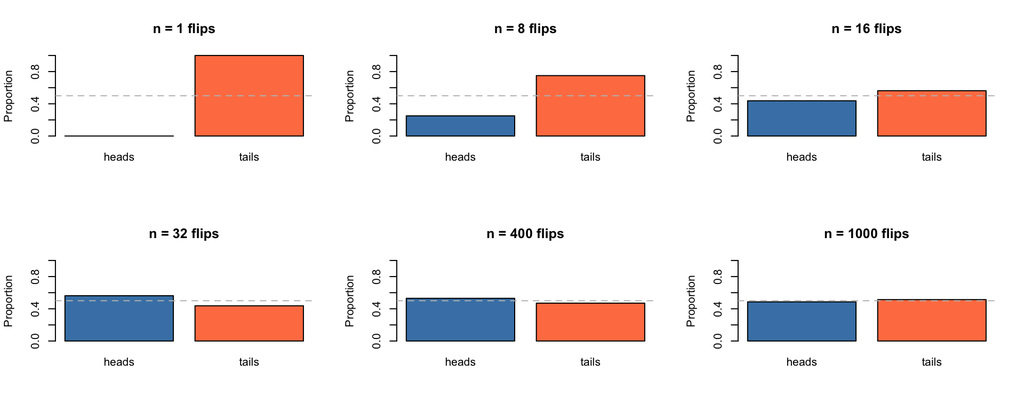

```r
set.seed(344)
par(mfrow = c(2, 3))

# Different sample sizes
for(n in c(1, 8, 16, 32, 400, 1000)) {
  flips <- rbinom(n = n, size = 1, prob = 0.5)  # 0 = heads, 1 = tails
  prop_heads <- sum(flips == 0) / length(flips)
  prop_tails <- 1 - prop_heads

  barplot(height = c(prop_heads, prop_tails),
          names.arg = c("heads", "tails"),
          col = c("steelblue", "coral"),
          ylim = c(0, 1),
          main = paste("n =", n, "flips"),
          ylab = "Proportion")
  abline(h = 0.5, lty = 2, col = "gray")
}
```

- With very small samples (n=1 or 8), the observed proportion of heads can deviate substantially from 0.5
- As sample size increases (n=400, 1000), the observed proportions converge tightly around the true probability of 0.5
- This demonstrates the Law of Large Numbers: sample statistics approach population parameters as n grows

**Tip**

As sample size increases, observed proportions converge to true probability (0.5).

## Law of Large Numbers in R

- Output
- Code
- Interpretation

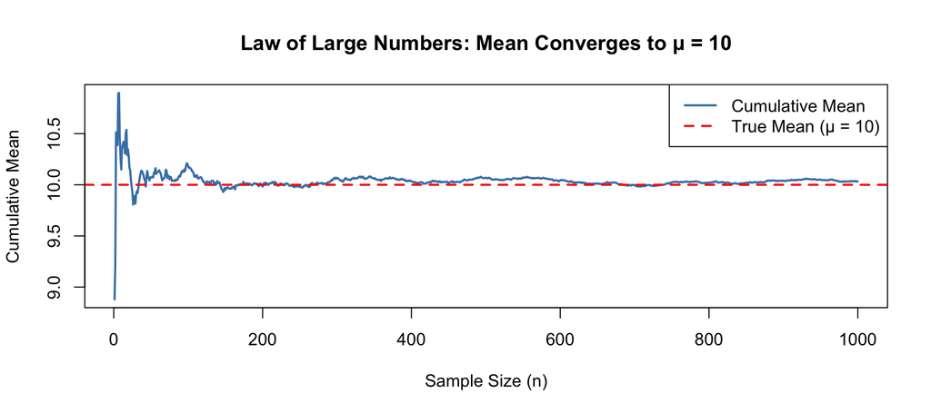

Figure 4: Sample means converge to population mean as sample size increases

```r
# Simulate cumulative means from a Normal(10, 2) population
set.seed(123)
n <- 1000
samples <- rnorm(n, mean = 10, sd = 2)
cumulative_means <- cumsum(samples) / 1:n

plot(1:n, cumulative_means, type = "l", col = "steelblue", lwd = 2,
     xlab = "Sample Size (n)", ylab = "Cumulative Mean",
     main = "Law of Large Numbers: Mean Converges to μ = 10")
abline(h = 10, col = "red", lwd = 2, lty = 2)
legend("topright", c("Cumulative Mean", "True Mean (μ = 10)"),
       col = c("steelblue", "red"), lwd = 2, lty = c(1, 2))
```

- The cumulative mean starts with high variability when n is small and progressively stabilizes as more samples are added
- The blue line converges toward the red dashed line (true mean of 10), demonstrating the Law of Large Numbers
- This convergence is the mathematical foundation for why larger sample sizes produce more reliable estimates

## Binomial Distribution

Results from combining several independent Bernoulli events.

- Equation
- LaTeX
- Interpretation

$$\large f(k) = {n \choose k} p^{k} (1-p)^{n-k}$$

```
\large f(k) = {n \choose k} p^{k} (1-p)^{n-k}
```

- The binomial formula gives the probability of exactly k successes in n independent Bernoulli trials
- The binomial coefficient counts the number of ways to arrange k successes among n trials
- The terms p^k and (1-p)^(n-k) give the probability of any one specific arrangement of k successes and n-k failures

Where:

- $n$ = total number of trials
- $k$ = number of successes
- $p$ = probability of success

## Binomial Distribution

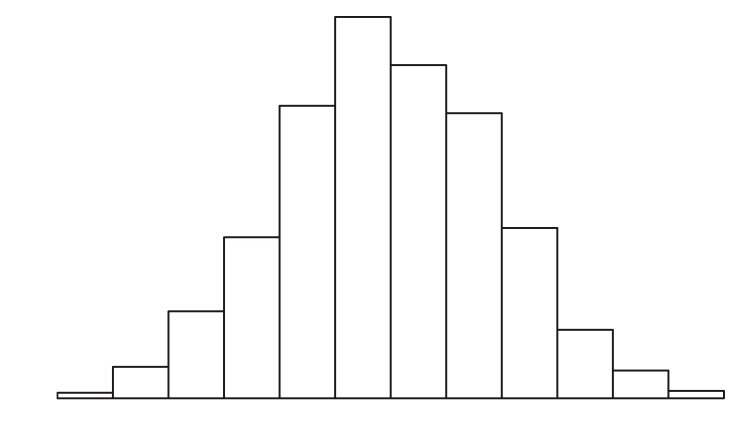

## Binomial Distribution (SVG)

[figure not shown]

## DRAFT: Binomial Distribution - Bell Shape

- Output
- Code
- Interpretation

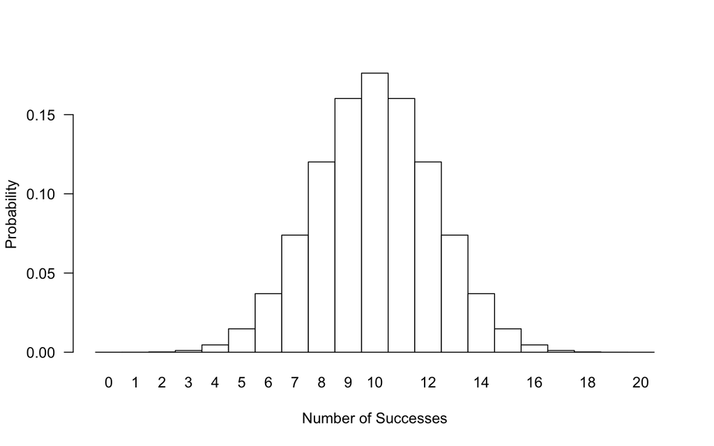

```r
# Binomial distribution that produces a bell shape
n <- 20
p <- 0.5
x <- 0:n
probs <- dbinom(x, size = n, prob = p)

barplot(probs, names.arg = x, col = "white", border = "black",
        xlab = "Number of Successes", ylab = "Probability",
        main = "", las = 1, space = 0)
```

- With n=20 trials and p=0.5, the binomial distribution forms a symmetric bell shape centered at 10 successes
- This bell shape foreshadows the normal distribution: as n increases, the binomial increasingly resembles a Gaussian curve
- The symmetry arises because p=0.5; with unequal p, the distribution would be skewed

## Creating a Binomial Distributions

- Output
- Code
- Interpretation

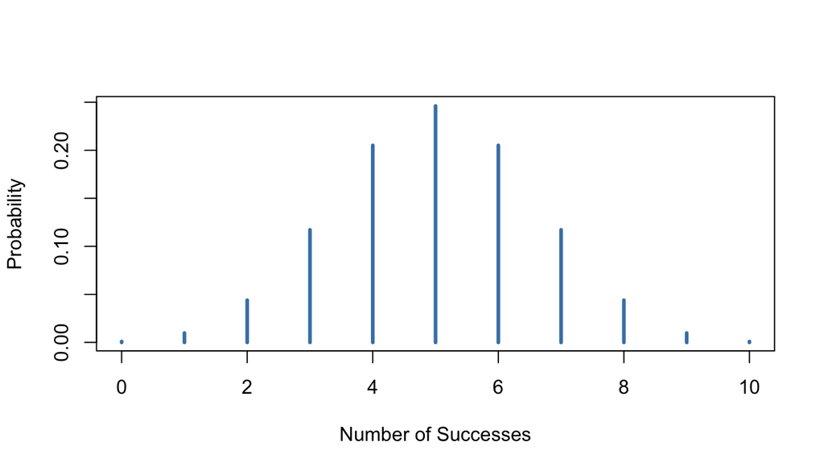

```r
# Probability of exactly 5 successes in 10 trials
dbinom(x = 5, size = 10, prob = 0.5)

# Plot distribution
plot(0:10, dbinom(x = 0:10, size = 10, prob = 0.5),
     type = "h", lwd = 3, col = "steelblue",
     xlab = "Number of Successes", ylab = "Probability")
```

- The `dbinom()` function calculates the exact probability of k successes in n independent trials
- With 10 fair coin flips (p=0.5), getting exactly 5 heads has the highest probability, but outcomes of 4 or 6 are nearly as likely
- The symmetric distribution centered at np=5 reflects the equal probability of success and failure

## Poisson Distribution

For discrete counts (e.g., snails per plot, neuron firings per second).

- Equation
- LaTeX
- Interpretation

$$Pr(Y=r) = \frac{e^{-\lambda}\lambda^r}{r!}$$

```
Pr(Y=r) = \frac{e^{-\lambda}\lambda^r}{r!}
```

- The Poisson distribution models the number of events occurring in a fixed interval when events happen independently at a constant rate
- It is uniquely defined by a single parameter lambda, which equals both the mean and the variance
- Common applications include counting mutations per gene, cells per grid square, or neuron firings per second

**Note**

The Poisson is a single-parameter distribution: $\mu = \sigma^2 = \lambda$

Variables with variance > mean are called “overdispersed” (common in RNA-seq data).

## Poisson Distribution Examples

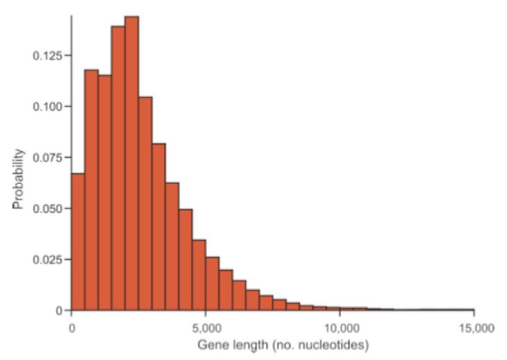

Gene length by 500 nt bins

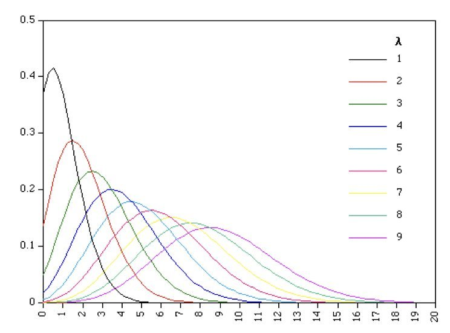

Increasing λ values

Source: Whitlock & Schluter, *The Analysis of Biological Data*

## DRAFT: Poisson Distribution Examples

- Output
- Code
- Interpretation

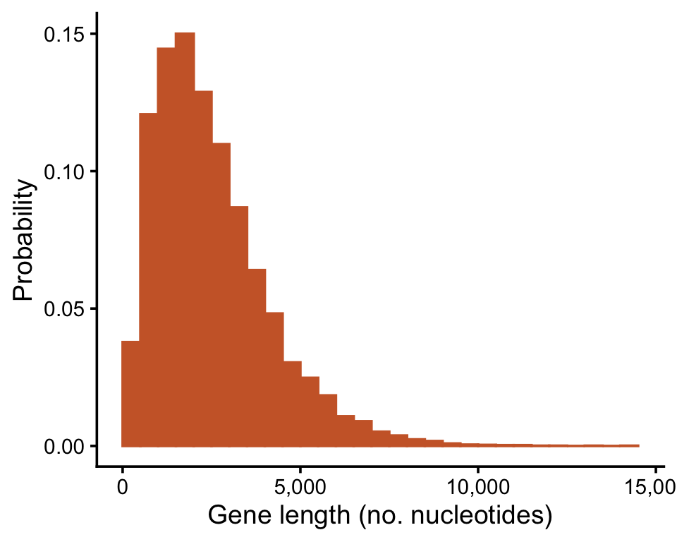

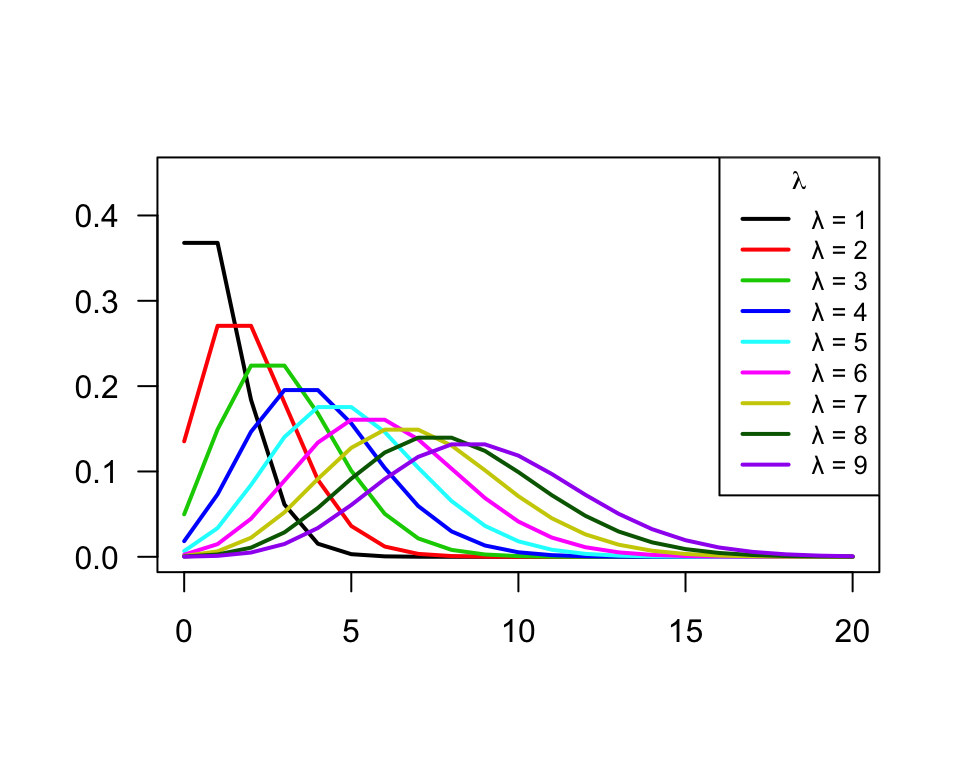

```r
# Left panel: gene length distribution (gamma-distributed)
set.seed(42)
gene_lengths <- rgamma(10000, shape = 2.5, rate = 0.001)
gene_lengths <- gene_lengths[gene_lengths <= 15000]

ggplot(data.frame(length = gene_lengths), aes(x = length)) +
  geom_histogram(aes(y = after_stat(count) / sum(after_stat(count))),
                 binwidth = 500, fill = "#CC6633", color = "#CC6633")

# Right panel: Poisson distributions with different lambda values
x <- 0:20
lambdas <- 1:9
plot(x, dpois(x, lambda = 1), type = "l", lwd = 2, ylim = c(0, 0.45))
for (i in 2:length(lambdas)) {
  lines(x, dpois(x, lambda = lambdas[i]), col = colors[i], lwd = 2)
}
```

- The left panel shows gene length data following a right-skewed (gamma) distribution, which is typical of biological count and size data
- The right panel shows how Poisson distributions change with lambda: small lambda values produce highly right-skewed distributions, while larger lambda values produce more symmetric, bell-shaped curves
- As lambda increases, the Poisson distribution converges toward a normal distribution, another illustration of the CLT

## Creating Poisson Distributions

- Output
- Code
- Interpretation

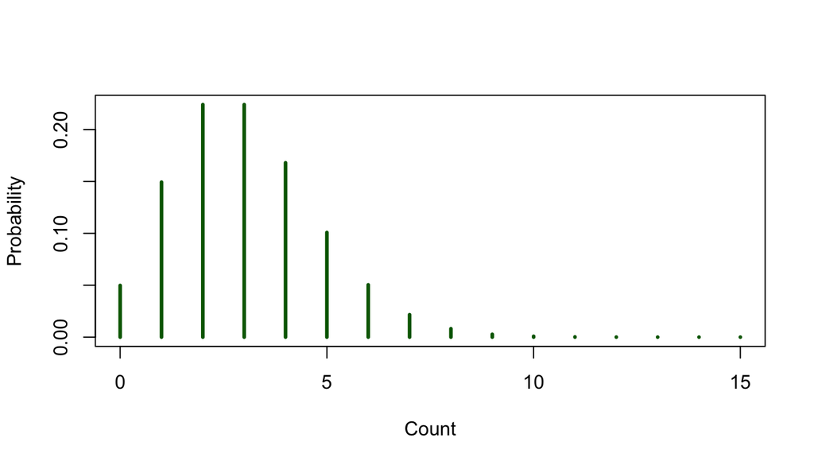

```r
# Probability of 2 counts given lambda = 1
dpois(x = 2, lambda = 1)

# Plot distribution
plot(0:15, dpois(x = 0:15, lambda = 3),
     type = "h", lwd = 3, col = "darkgreen",
     xlab = "Count", ylab = "Probability")
```

- The `dpois()` function calculates the probability of observing exactly r events given a rate lambda
- With lambda=3, the distribution peaks near x=3 and is slightly right-skewed, showing that counts near the mean are most probable
- The distribution only takes non-negative integer values, reflecting that counts cannot be negative or fractional

## Geometric Distribution

Probability of observing $k$ trials before the first success:

- Equation
- LaTeX
- Interpretation

$$P(X=k)=(1-p)^{k-1}p$$

```
P(X=k)=(1-p)^{k-1}p
```

- The geometric distribution models the number of independent trials until the first success
- Like the exponential distribution, it is memoryless: past failures do not affect the probability of future success
- With probability p=0.1, the expected number of trials until the first success is 1/p = 10
- Mean = $\frac{1}{p}$
- Variance = $\frac{(1-p)}{p^2}$

**Example:** If extinction probability is 0.1 per year, expected time to extinction?

## Negative Binomial Distribution

Probability of the $r^{th}$ success on the $k^{th}$ trial:

- Equation
- LaTeX
- Interpretation

$$P(X=k)=\binom{k-1}{r-1}p^{r}(1-p)^{k-r}$$

```
P(X=k)=\binom{k-1}{r-1}p^{r}(1-p)^{k-r}
```

- The negative binomial models the number of trials needed to achieve a fixed number of successes
- It generalizes the geometric distribution (which is the special case r=1)
- In biology, it is widely used to model overdispersed count data such as RNA-seq read counts, where variance exceeds the mean
- Mean = $\frac{r}{p}$
- Variance = $\frac{r(1-p)}{p^2}$

# Continuous Probability Distributions

## Continuous Probability Distributions

- Equation
- LaTeX
- Interpretation

$$P(a\leq X \leq b) = \int_{a}^{b} f(x) dx$$

The indefinite integral sums to one:

$$\int_{-\infty}^{\infty} f(x) dx = 1$$

**Expectation:**
$$E[X] = \int_{-\infty}^{\infty} xf(x) dx$$

```
P(a\leq X \leq b) = \int_{a}^{b} f(x) dx

\int_{-\infty}^{\infty} f(x) dx = 1

E[X] = \int_{-\infty}^{\infty} xf(x) dx
```

- For continuous distributions, probabilities are defined as areas under the curve between two values, not as point probabilities
- The total area under the probability density function must equal 1 (certainty)
- The expectation (mean) is the integral-weighted average of all possible values

## Uniform Distribution

All outcomes equally probable.

- Equation
- LaTeX
- Interpretation

$$E[X] = \frac{(a+b)}{2}$$

```
E[X] = \frac{(a+b)}{2}
```

- The expected value of a uniform distribution is simply the midpoint of the interval [a, b]
- This reflects the symmetry: all values are equally likely, so the average must be the center
- Output
- Code
- Interpretation

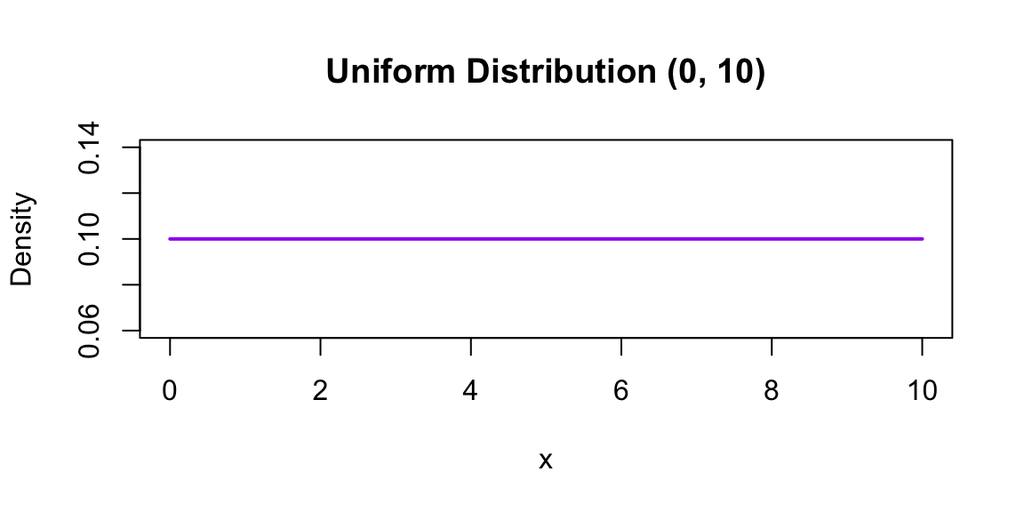

```r
x <- seq(0, 10, 0.1)
plot(x, dunif(x, 0, 10), type = "l", lwd = 2, col = "purple",
     ylab = "Density", main = "Uniform Distribution (0, 10)")
```

- The flat density line shows that every value between 0 and 10 is equally likely
- The density equals 1/(b-a) = 0.1, ensuring the total area under the curve sums to 1
- The uniform distribution is often used as a baseline or “uninformative” prior in Bayesian analysis

## Exponential Distribution

- Equation
- LaTeX
- Interpretation

$$f(x)=\lambda e^{-\lambda x}$$

```
f(x)=\lambda e^{-\lambda x}
```

- The exponential distribution models waiting times between events in a Poisson process
- The rate parameter lambda determines both the mean (1/lambda) and standard deviation (1/lambda)
- It is “memoryless”: the probability of an event in the next interval is independent of how long you have already waited
- $E[X] = \frac{1}{\lambda}$
- $Var(X) = \frac{1}{\lambda^2}$

**Example:** If λ equals the instantaneous death rate, the lifespan follows an exponential distribution.

## Exponential Distribution

- Output
- Code
- Interpretation

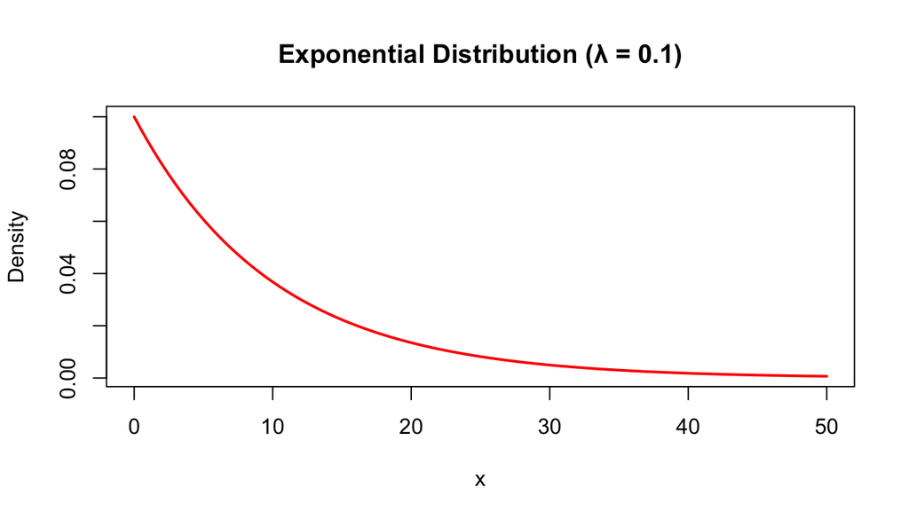

```r
x <- seq(0, 50, 0.5)
plot(x, dexp(x, rate = 0.1), type = "l", lwd = 2, col = "red",
     ylab = "Density", main = "Exponential Distribution (λ = 0.1)")
```

- The density is highest near zero and decreases exponentially, meaning short waiting times are most probable
- With rate=0.1, the expected waiting time is 1/0.1 = 10 units
- The long right tail reflects that occasional very long waiting times are possible but increasingly unlikely

## Gamma Distribution

Waiting time until the $r^{th}$ event at rate $\lambda$:

- Equation
- LaTeX
- Interpretation

$$f(x) = \frac{\lambda^r x^{r-1} e^{-\lambda x}}{(r-1)!}$$

```
f(x) = \frac{\lambda^r x^{r-1} e^{-\lambda x}}{(r-1)!}
```

- The gamma distribution generalizes the exponential to model waiting times until multiple events occur
- The shape parameter r controls the number of events; the rate parameter lambda controls how fast events happen
- When r=1, the gamma reduces to the exponential distribution
- Mean = $\frac{r}{\lambda}$
- Variance = $\frac{r}{\lambda^2}$

**Example:** Time until 1000 DNA strands synthesized at rate 1/ms.

# The Normal or Gaussian Distribution

## Normal (Gaussian) Distribution

- Equation
- LaTeX
- Interpretation

$$f(x) = \frac{1}{\sqrt{2\pi\sigma^2}} \, \mathrm{e}^{-\frac{(x - \mu)^2}{2\sigma^2}}$$

```
f(x) = \frac{1}{\sqrt{2\pi\sigma^2}} \, \mathrm{e}^{-\frac{(x - \mu)^2}{2\sigma^2}}
```

- The normal (Gaussian) distribution is a symmetric, bell-shaped curve fully described by two parameters: mean and variance
- The exponential term creates the bell shape by assigning highest probability density near the mean and decreasing probability as values move further away
- Many biological measurements approximate this distribution due to the Central Limit Theorem

Notation: $v \sim \mathcal{N}(\mu, \sigma^2)$

## Normal Distribution

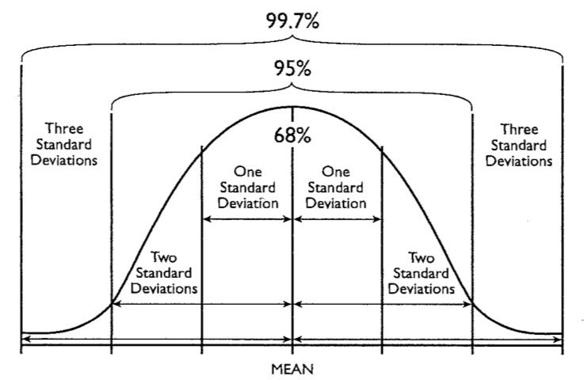

## Normal Distribution (SVG)

[figure not shown]

## DRAFT: Normal Distribution - 68-95-99.7 Rule

- Output
- Code
- Interpretation

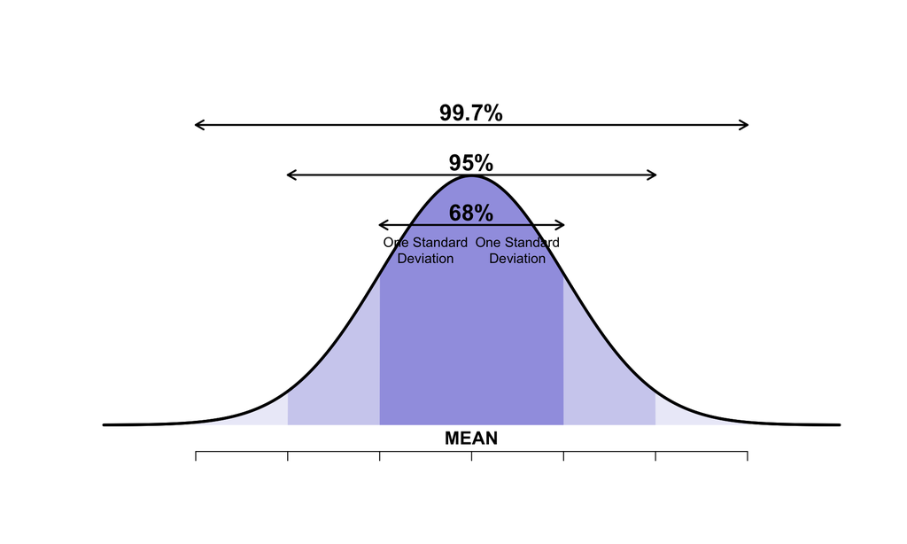

```r
x <- seq(-4, 4, length.out = 1000)
y <- dnorm(x)

plot(x, y, type = "l", lwd = 3, axes = FALSE,
     xlab = "", ylab = "", ylim = c(-0.02, max(y) * 1.35))

# Shade 99.7% region (3 SD)
x_99 <- x[x >= -3 & x <= 3]
polygon(c(-3, x_99, 3), c(0, dnorm(x_99), 0),
        col = rgb(0.85, 0.85, 0.95, 0.5), border = NA)
# Shade 95% region (2 SD)
x_95 <- x[x >= -2 & x <= 2]
polygon(c(-2, x_95, 2), c(0, dnorm(x_95), 0),
        col = rgb(0.7, 0.7, 0.9, 0.5), border = NA)
# Shade 68% region (1 SD)
x_68 <- x[x >= -1 & x <= 1]
polygon(c(-1, x_68, 1), c(0, dnorm(x_68), 0),
        col = rgb(0.5, 0.5, 0.85, 0.6), border = NA)
```

- The 68-95-99.7 rule states that approximately 68% of data falls within 1 SD of the mean, 95% within 2 SD, and 99.7% within 3 SD
- This rule provides quick probability estimates without needing to compute integrals
- Values beyond 3 standard deviations are extremely rare (0.3%), which is why they are often flagged as potential outliers

## Normal Distribution

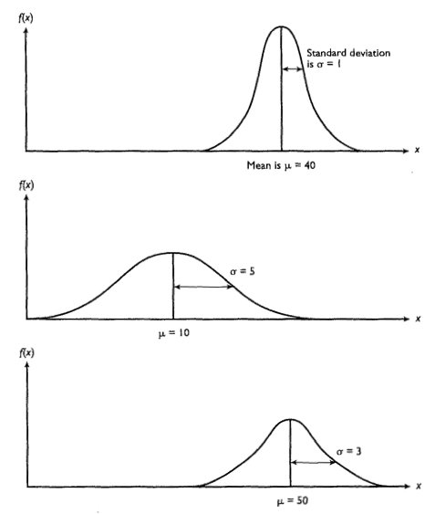

## Normal Distribution (SVG)

[figure not shown]

## DRAFT: Normal Distributions - Varying Parameters

- Output
- Code
- Interpretation

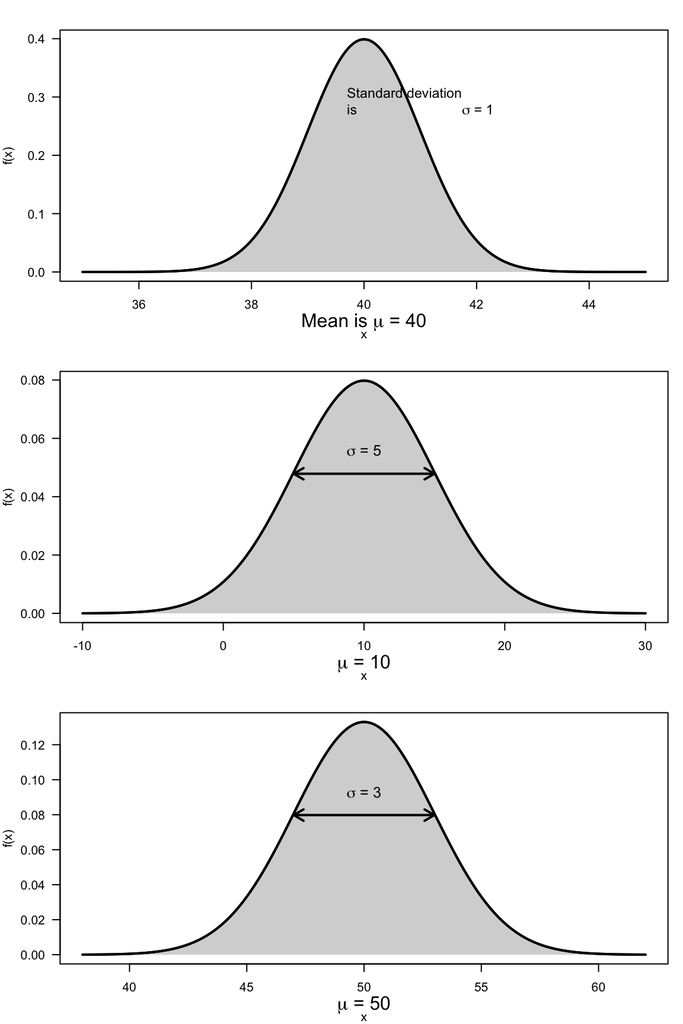

```r
par(mfrow = c(3, 1), mar = c(4, 4, 2, 1))

# Normal with mu=40, sigma=1
x1 <- seq(35, 45, length.out = 300)
plot(x1, dnorm(x1, mean = 40, sd = 1), type = "l", lwd = 2,
     xlab = "x", ylab = "f(x)")

# Normal with mu=10, sigma=5
x2 <- seq(-10, 30, length.out = 300)
plot(x2, dnorm(x2, mean = 10, sd = 5), type = "l", lwd = 2,
     xlab = "x", ylab = "f(x)")

# Normal with mu=50, sigma=3
x3 <- seq(38, 62, length.out = 300)
plot(x3, dnorm(x3, mean = 50, sd = 3), type = "l", lwd = 2,
     xlab = "x", ylab = "f(x)")
```

- Changing the mean shifts the distribution left or right along the x-axis without altering its shape
- Changing the standard deviation controls the spread: smaller sigma produces a taller, narrower curve; larger sigma produces a shorter, wider curve
- The total area under each curve equals 1, regardless of the parameter values

## Why is the Normal Distribution Special?

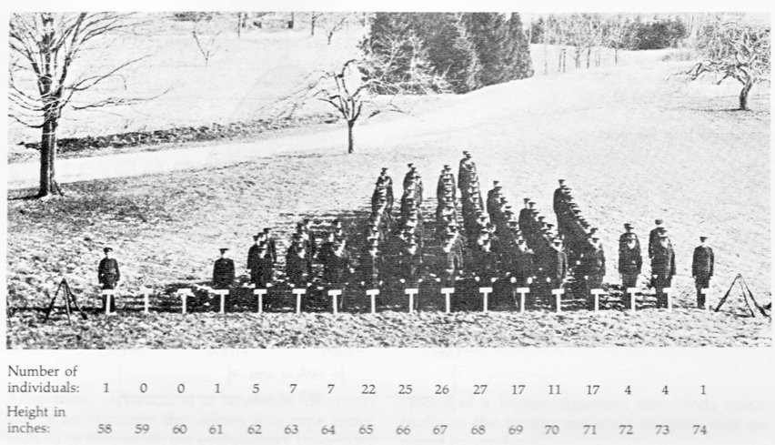

Source: Classroom demonstration photograph

## Why Normal is Special in Biology

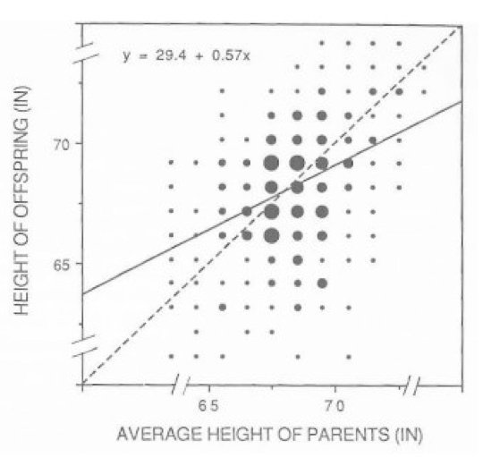

Source: Francis Galton, 1886; data from Galton’s height study

## DRAFT: Galton’s Regression to the Mean

- Output
- Code
- Interpretation

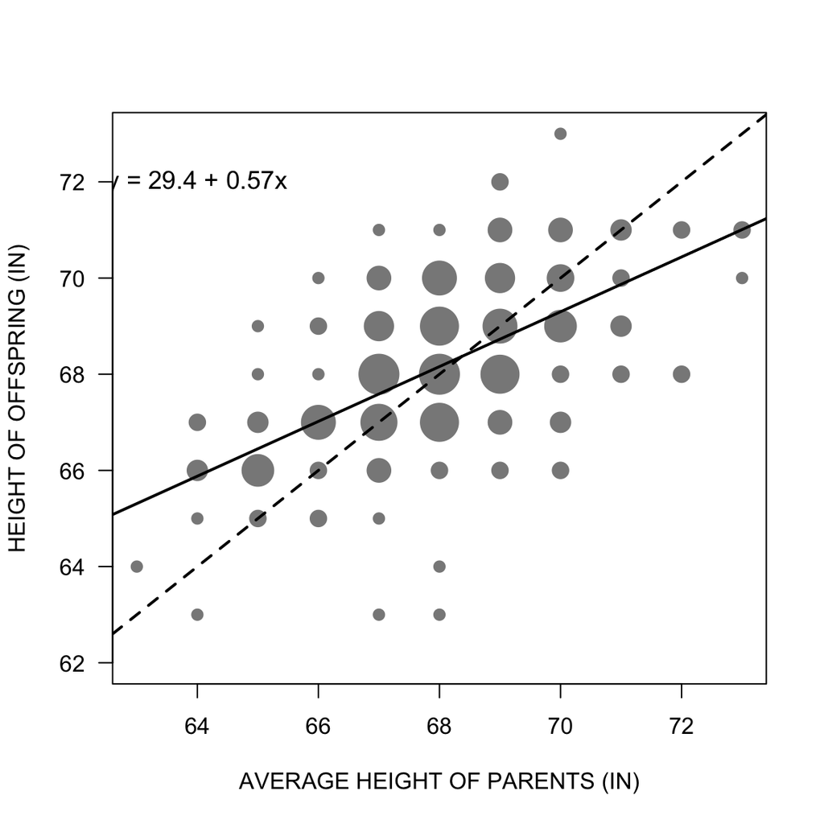

```r
# Recreate Galton's parent-offspring height data (approximate)
set.seed(1885)
n <- 200
parent_height <- rnorm(n, mean = 68, sd = 2)
offspring_height <- 29.4 + 0.57 * parent_height + rnorm(n, 0, 1.5)

# Create bubble-like effect by rounding
parent_r <- round(parent_height)
offspring_r <- round(offspring_height)

df <- data.frame(parent = parent_r, offspring = offspring_r)
df_counts <- as.data.frame(table(df$parent, df$offspring))

plot(df_counts$parent, df_counts$offspring,
     cex = sqrt(df_counts$count) * 1.2,
     pch = 16, col = rgb(0.3, 0.3, 0.3, 0.7),
     xlab = "AVERAGE HEIGHT OF PARENTS (IN)",
     ylab = "HEIGHT OF OFFSPRING (IN)")

# Regression line vs 1:1 line
abline(a = 29.4, b = 0.57, lwd = 2)
abline(a = 0, b = 1, lwd = 2, lty = 2)
```

- The regression line (solid) has a slope of 0.57, less than the 1:1 line (dashed), demonstrating regression to the mean
- Tall parents tend to have offspring shorter than themselves; short parents tend to have taller offspring
- This phenomenon occurs because extreme values arise partly from chance, and offspring “regress” toward the population mean

## Why Normal is Special in Biology

[figure not shown]

Source: Birth data visualization

## Z-Scores of Normal distributions

Standardize variables to mean = 0, SD = 1:

- Equation
- LaTeX
- Interpretation

$$\huge z_i = \frac{(x_i - \bar{x})}{s}$$

```
\huge z_i = \frac{(x_i - \bar{x})}{s}
```

- A z-score expresses how many standard deviations a value lies from the mean
- Standardizing allows comparison of values from distributions with different means and spreads
- The resulting standard normal distribution (mean=0, SD=1) is the basis for many statistical tests

This is the **standard normal distribution**.

# Sampling from distributions in R

## Distribution Functions in R

| Prefix | Function | Example |
| --- | --- | --- |
| `d` | Probability density/mass | `dnorm(0, 0, 1)` |
| `p` | Cumulative distribution | `pnorm(1.96, 0, 1)` |
| `q` | Quantile function | `qnorm(0.975, 0, 1)` |
| `r` | Random number generator | `rnorm(100, 0, 1)` |

Works for: `binom`, `pois`, `exp`, `norm`, `geom`, `nbinom`, `unif`, `gamma`

# Estimates and Confidence Intervals

## Parameter Estimation

- Estimation infers population parameters from sample data
- Sample estimates rarely equal population parameters exactly
- **Sampling distribution**: all values we might obtain from samples
- **Standard error**: standard deviation of sampling distribution

**Important**

NO ESTIMATE IS USEFUL WITHOUT A STANDARD ERROR!

## Estimation Approaches

| Approach | Description |
| --- | --- |
| **Parametric** | Assumes specific distributions |
| **Resampling** | Bootstrap/randomization for empirical distributions |
| **OLS** | Ordinary Least Squares optimization |
| **Maximum Likelihood** | Model-based estimates with confidence |
| **Bayesian** | Incorporates prior information |

## The Central Limit Theorem

For most data, we can’t determine sampling distributions empirically.

The CLT tells us that the sampling distribution of the mean approaches normal as sample size increases, regardless of the underlying distribution.

## Visualizing the Central Limit Theorem

- Output
- Code
- Interpretation
- Try It

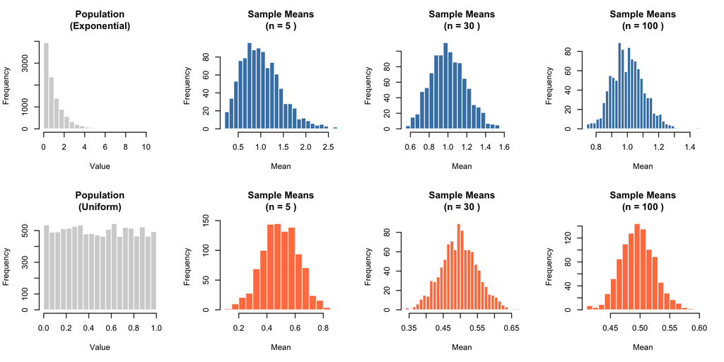

Figure 5: CLT: Sample means become normal even from non-normal populations

```r
par(mfrow = c(2, 4))

# Exponential distribution (skewed)
set.seed(42)
exp_pop <- rexp(10000, rate = 1)
hist(exp_pop, main = "Population\n(Exponential)", col = "lightgray",
     border = "white", xlab = "Value", breaks = 30)

# Sample means for different n
for(n in c(5, 30, 100)) {
  means <- replicate(1000, mean(sample(exp_pop, n, replace = TRUE)))
  hist(means, main = paste("Sample Means\n(n =", n, ")"),
       col = "steelblue", border = "white", xlab = "Mean", breaks = 25)
}

# Uniform distribution
unif_pop <- runif(10000, 0, 1)
hist(unif_pop, main = "Population\n(Uniform)", col = "lightgray",
     border = "white", xlab = "Value", breaks = 30)

for(n in c(5, 30, 100)) {
  means <- replicate(1000, mean(sample(unif_pop, n, replace = TRUE)))
  hist(means, main = paste("Sample Means\n(n =", n, ")"),
       col = "coral", border = "white", xlab = "Mean", breaks = 25)
}
```

- The leftmost panels show the original population distributions: exponential (heavily right-skewed) and uniform (flat)
- As sample size increases from n=5 to n=100, the distribution of sample means becomes increasingly bell-shaped regardless of the original distribution
- By n=30, the sampling distribution is approximately normal, which is why n=30 is often cited as a practical threshold for CLT to take effect

```r
# Try with a bimodal population - how does the CLT perform?
set.seed(42)
bimodal_pop <- c(rnorm(5000, mean = 3, sd = 1), rnorm(5000, mean = 8, sd = 1))
hist(bimodal_pop, main = "Bimodal Population", col = "lightgray", breaks = 40)

# Sample means at different n
par(mfrow = c(1, 3))
for(n in c(5, 30, 100)) {
  means <- replicate(1000, mean(sample(bimodal_pop, n, replace = TRUE)))
  hist(means, main = paste("Sample Means (n =", n, ")"),
       col = "steelblue", border = "white", breaks = 25)
}
# Question: At what n does the bimodal shape disappear in the sampling distribution?
```

## CLT in Action: Watch the Sampling Distribution Build

This animation shows repeated sampling from a **skewed exponential population** (left). Each sample of n=25 produces a mean, which is added to the histogram on the right. Watch how:

- The **distribution of means** becomes bell-shaped despite the skewed population
- The **estimate** (red line) converges toward the true μ
- The **SEM** (green bracket) shrinks as more samples are drawn

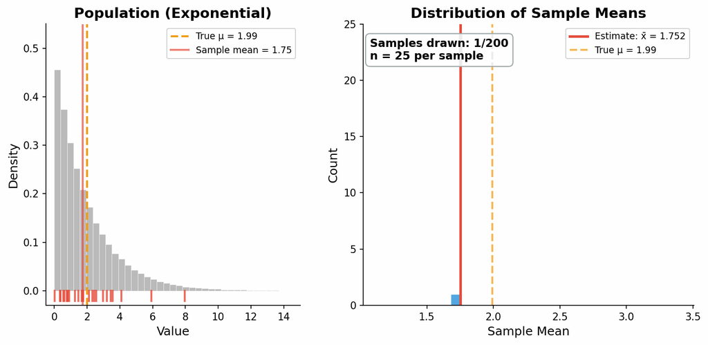

Source: CLT sampling animation created with Python/matplotlib

## CLT in Quantitative Genetics

**Why are complex traits normally distributed?**

Simulate a trait controlled by 5 genes, each with additive effects:

- Output
- Code
- Interpretation

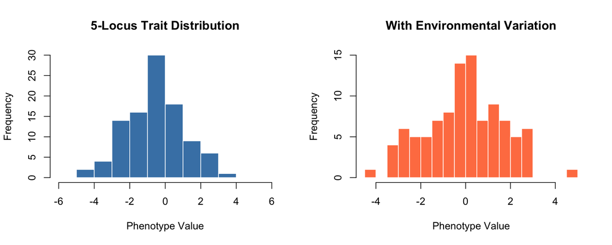

```r
set.seed(245)
n_individuals <- 100

# Each locus contributes -1, 0, or +1 to phenotype (diploid genotypes)
contributions <- matrix(0, nrow = n_individuals, ncol = 5)
for(locus in 1:5) {
  genotype <- rbinom(n_individuals, size = 2, prob = 0.5)  # 0, 1, or 2 copies
  contributions[, locus] <- ifelse(genotype == 2, 1,
                                    ifelse(genotype == 1, 0, -1))
}

# Sum across loci to get phenotype
phenotype <- rowSums(contributions)

par(mfrow = c(1, 2))
hist(phenotype, col = "steelblue", border = "white",
     main = "5-Locus Trait Distribution",
     xlab = "Phenotype Value", breaks = seq(-6, 6, 1))

# Add environmental noise to make continuous
phenotype_continuous <- phenotype + rnorm(n_individuals, 0, 0.5)
hist(phenotype_continuous, col = "coral", border = "white",
     main = "With Environmental Variation",
     xlab = "Phenotype Value", breaks = 20)
```

- The left panel shows that even with only 5 loci, summing discrete genetic effects produces a roughly bell-shaped distribution
- Adding environmental noise (right panel) smooths the distribution into an approximately normal shape
- This demonstrates why the CLT explains the normal distribution of complex traits: many small, independent genetic and environmental effects sum to produce a Gaussian outcome

**Note**

This is why quantitative traits (height, weight, blood pressure) are approximately normal!

# Sampling variation of a parameter estimate

## Sampling Variation of a Parameter

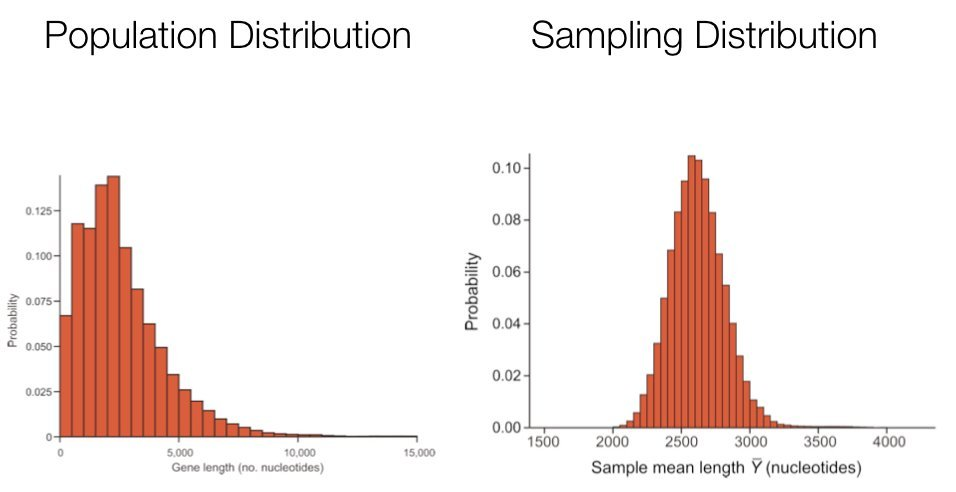

Source: Whitlock & Schluter, *The Analysis of Biological Data*

## DRAFT: Population vs Sampling Distribution

- Output
- Code
- Interpretation

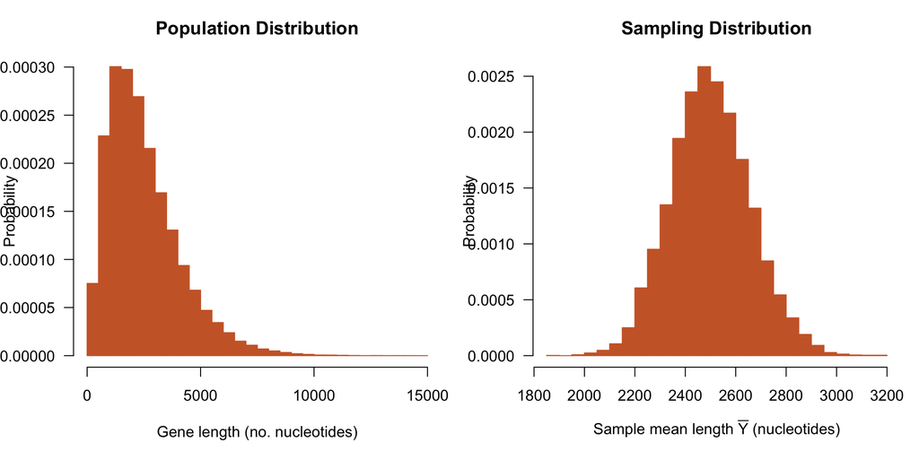

```r
# Simulate gene length data (right-skewed gamma)
set.seed(42)
pop_data <- rgamma(100000, shape = 2.5, rate = 0.001)
pop_data <- pop_data[pop_data <= 15000]
pop_mean <- mean(pop_data)

# Sampling distribution: means of samples of n=100
sample_means <- replicate(10000, mean(sample(pop_data, 100)))

par(mfrow = c(1, 2), mar = c(5, 4, 3, 1))

# Left: Population distribution
hist(pop_data, breaks = seq(0, 15000, by = 500),
     col = "#CC6633", border = "#CC6633",
     main = "Population Distribution",
     xlab = "Gene length (no. nucleotides)", ylab = "Probability",
     freq = FALSE, las = 1)

# Right: Sampling distribution
hist(sample_means, breaks = 40,
     col = "#CC6633", border = "#CC6633",
     main = "Sampling Distribution",
     xlab = expression("Sample mean length " * bar(Y) * " (nucleotides)"),
     ylab = "Probability", freq = FALSE, las = 1)
```

- The left panel shows the population distribution of gene lengths, which is right-skewed (gamma-distributed)
- The right panel shows the sampling distribution of the mean from samples of n=100, which is approximately normal despite the skewed population
- This demonstrates the Central Limit Theorem: the distribution of sample means becomes normal regardless of the shape of the underlying population

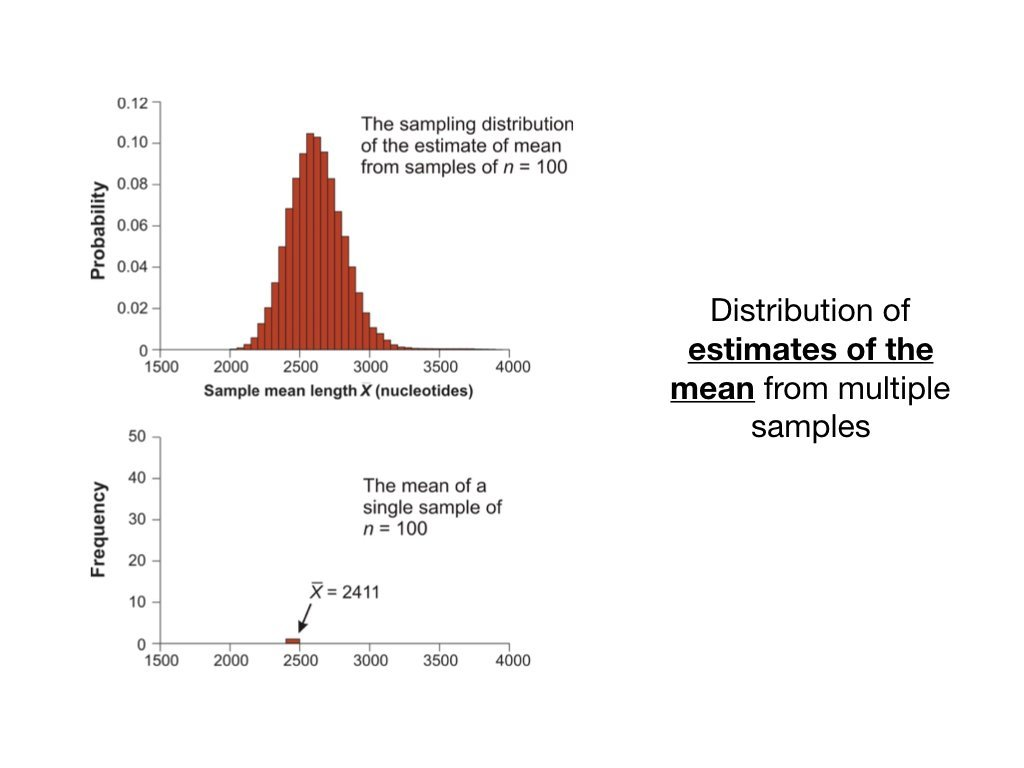

Source: Whitlock & Schluter, *The Analysis of Biological Data*

## DRAFT: Sampling Distribution of Means

- Output
- Code
- Interpretation

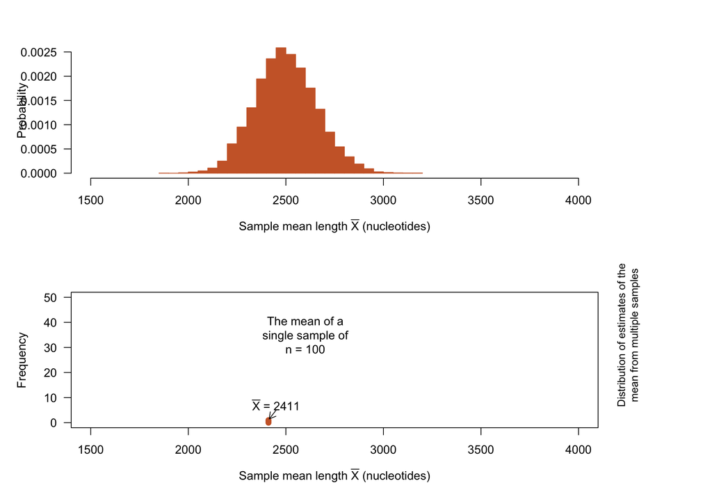

```r
set.seed(42)
pop_data <- rgamma(100000, shape = 2.5, rate = 0.001)
pop_data <- pop_data[pop_data <= 15000]
sample_means <- replicate(10000, mean(sample(pop_data, 100)))

par(mfrow = c(2, 1), mar = c(5, 5, 3, 8))

# Top: Sampling distribution
hist(sample_means, breaks = 40,
     col = "#CC6633", border = "#CC6633",
     main = "", xlim = c(1500, 4000),
     xlab = expression("Sample mean length " * bar(X) * " (nucleotides)"),
     ylab = "Probability", freq = FALSE, las = 1)

# Bottom: Single sample mean
plot(1, 1, type = "n", xlim = c(1500, 4000), ylim = c(0, 50),
     xlab = expression("Sample mean length " * bar(X) * " (nucleotides)"),
     ylab = "Frequency", las = 1, main = "")
segments(2411, 0, 2411, 1, lwd = 8, col = "#CC6633")
```

- The top panel shows the sampling distribution: the distribution of means from many samples of size n=100, which is approximately normal even though the population is skewed
- The bottom panel shows that any single sample mean is just one value drawn from this sampling distribution
- This highlights that our sample estimate is one realization from a distribution of possible estimates

## Estimation and Confidence Intervals

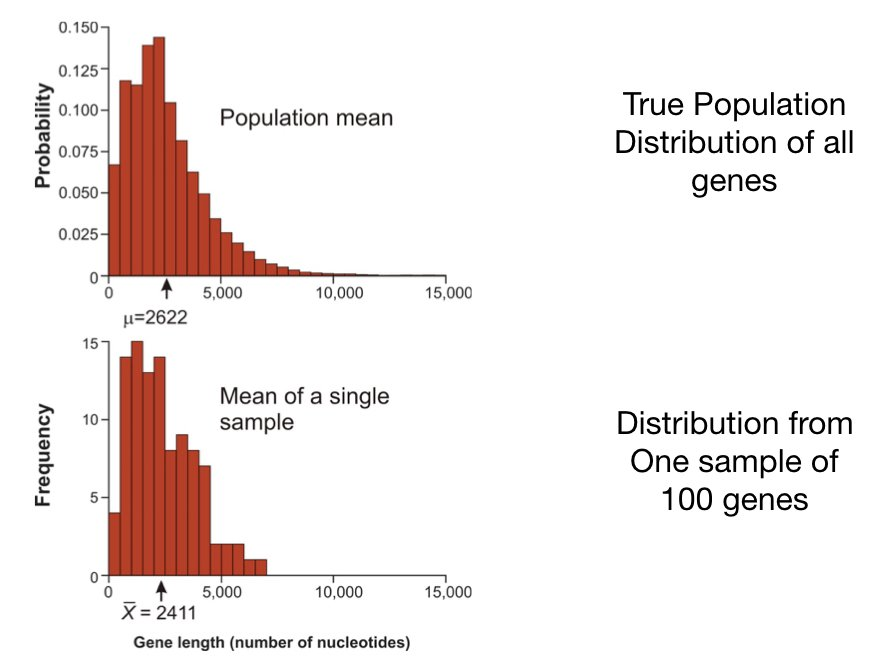

Source: Whitlock & Schluter, *The Analysis of Biological Data*

## DRAFT: Population vs Single Sample

- Output
- Code
- Interpretation

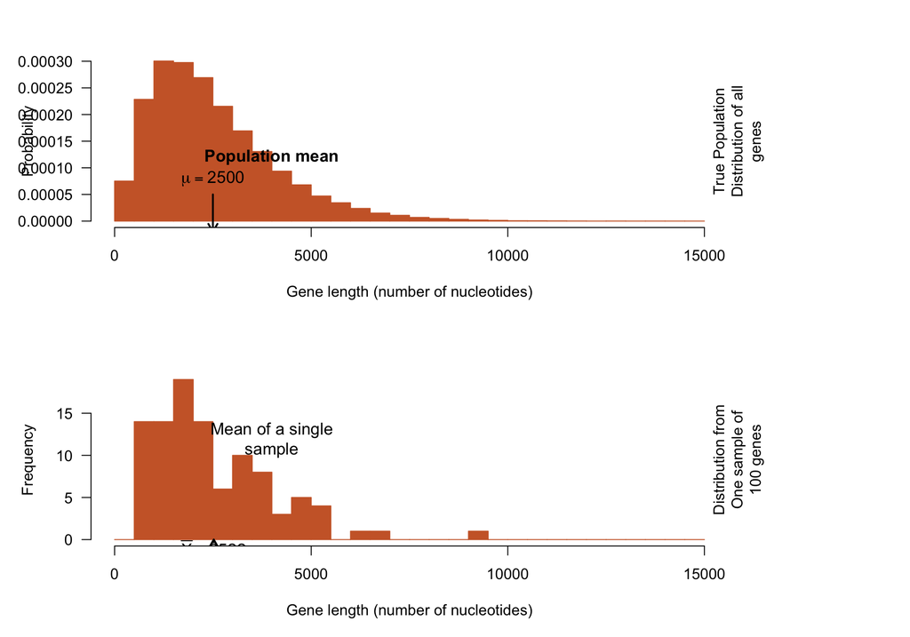

```r
set.seed(42)
pop_data <- rgamma(100000, shape = 2.5, rate = 0.001)
pop_data <- pop_data[pop_data <= 15000]
pop_mean <- mean(pop_data)

# Single sample
single_sample <- sample(pop_data, 100)
sample_mean <- round(mean(single_sample))

par(mfrow = c(2, 1), mar = c(5, 5, 3, 10))

# Top: Population distribution
hist(pop_data, breaks = seq(0, 15000, by = 500),
     col = "#CC6633", border = "#CC6633",
     main = "", xlab = "Gene length (number of nucleotides)",
     ylab = "Probability", freq = FALSE, las = 1)

# Bottom: Single sample
hist(single_sample, breaks = seq(0, 15000, by = 500),
     col = "#CC6633", border = "#CC6633",
     main = "", xlim = c(0, 15000),
     xlab = "Gene length (number of nucleotides)",
     ylab = "Frequency", las = 1)
```

- The top panel shows the true population distribution of gene lengths (right-skewed), with the population mean marked
- The bottom panel shows what we actually observe: a single sample of 100 genes, whose mean approximates but does not equal the true population mean
- This illustrates the fundamental challenge of statistics: we must infer population parameters from limited sample data

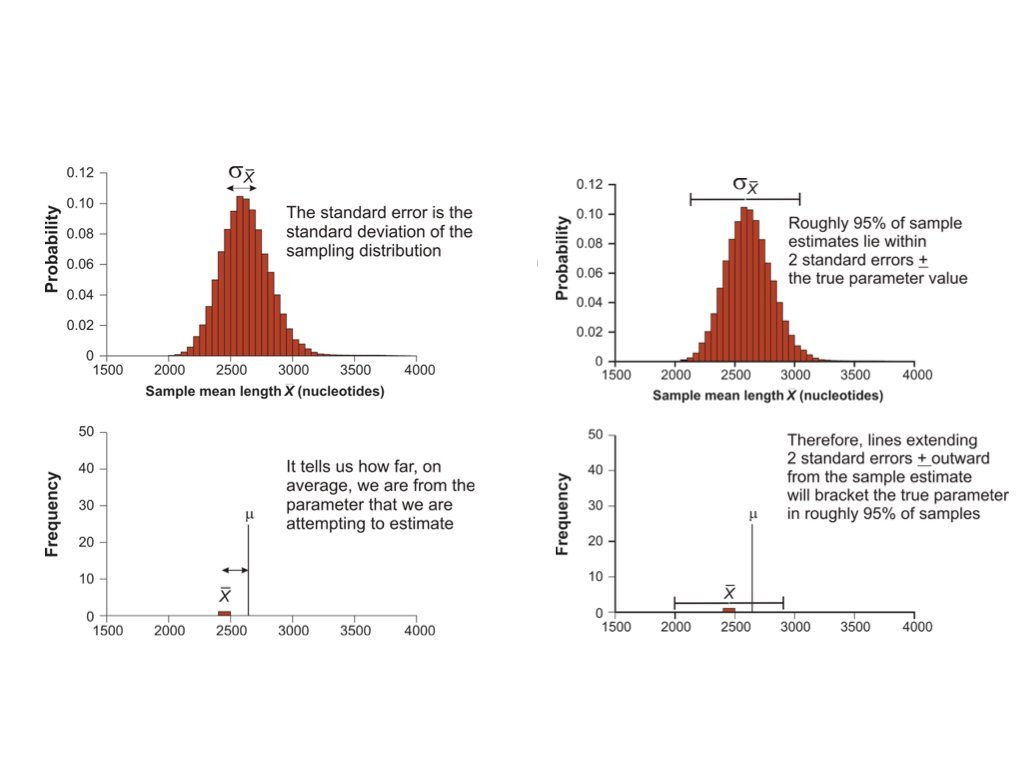

Source: Whitlock & Schluter, *The Analysis of Biological Data*

## DRAFT: Standard Error and Confidence Intervals

- Output
- Code
- Interpretation

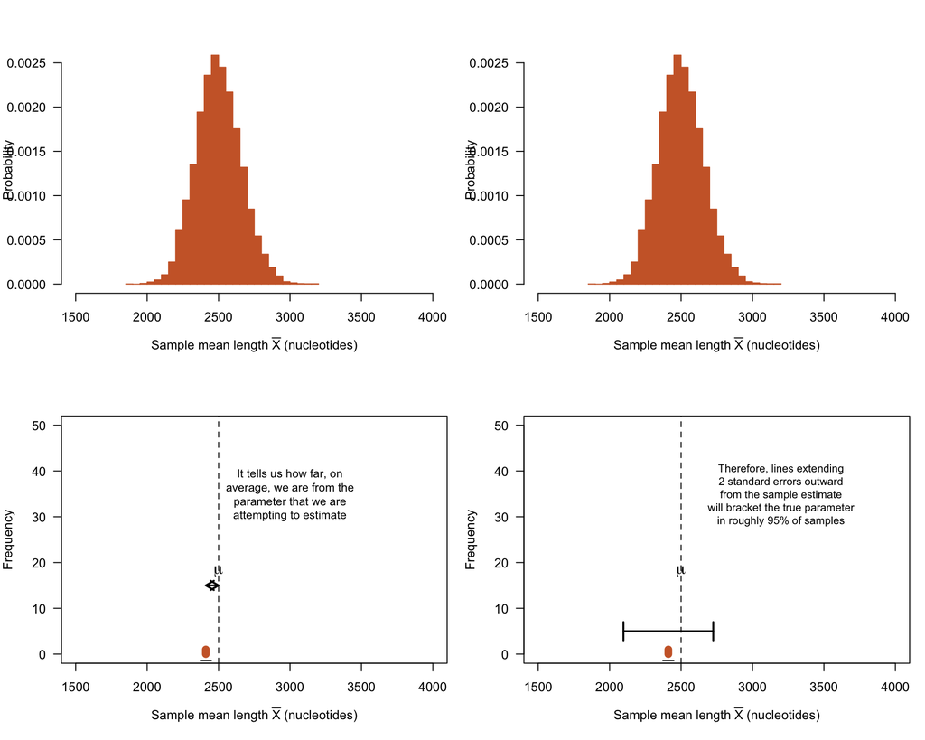

```r
set.seed(42)
pop_data <- rgamma(100000, shape = 2.5, rate = 0.001)
pop_data <- pop_data[pop_data <= 15000]
pop_mean <- mean(pop_data)
sample_means <- replicate(10000, mean(sample(pop_data, 100)))
se <- sd(sample_means)

par(mfrow = c(2, 2), mar = c(5, 4, 3, 1))

# Top-left: sampling distribution + SE arrow
hist(sample_means, breaks = 40, col = "#CC6633", border = "#CC6633",
     main = "", xlim = c(1500, 4000),
     xlab = expression("Sample mean length " * bar(X) * " (nucleotides)"),
     ylab = "Probability", freq = FALSE, las = 1)
arrows(pop_mean - se, 0.012, pop_mean + se, 0.012,
       code = 3, length = 0.1, lwd = 2)

# Top-right: sampling distribution + 2SE bracket
hist(sample_means, breaks = 40, col = "#CC6633", border = "#CC6633",
     main = "", xlim = c(1500, 4000),
     xlab = expression("Sample mean length " * bar(X) * " (nucleotides)"),
     ylab = "Probability", freq = FALSE, las = 1)
arrows(pop_mean - 2*se, 0.012, pop_mean + 2*se, 0.012,
       code = 3, length = 0.1, lwd = 2)

# Bottom panels: single sample with CI brackets
segments(2411 - 2*se, 5, 2411 + 2*se, 5, lwd = 2)
```

- The four panels progressively build the concept of standard error and confidence intervals
- The standard error (top-left) is the standard deviation of the sampling distribution, measuring typical distance between a sample estimate and the true parameter
- Extending 2 standard errors from a sample mean (bottom-right) creates a 95% confidence interval that brackets the true parameter in roughly 95% of samples

## Standard Error of the Mean

- Equation
- LaTeX
- Interpretation

$$\huge \sigma_{\bar{x}} \approx s_{\bar{x}} = \frac{s}{\sqrt{n}}$$

```
\huge \sigma_{\bar{x}} \approx s_{\bar{x}} = \frac{s}{\sqrt{n}}
```

- The standard error of the mean equals the sample standard deviation divided by the square root of the sample size
- SEM shrinks with larger samples because the square root of n is in the denominator
- SEM estimates how much the sample mean would vary across repeated samples from the same population

**Note**

- SEM is NOT the standard deviation of the original distribution
- SEM decreases as sample size increases

## Calculating SEM

- Output
- Code
- Interpretation

```
SEM (n=5): 0.2647
SEM (n=50): 0.0828
```

```r
set.seed(32)
true_pop <- rnorm(n = 1000, mean = 2, sd = 5)

# Small sample
samps_5 <- replicate(n = 50, sample(true_pop, size = 5))
sem_5 <- sd(apply(samps_5, 2, mean)) / sqrt(50)

# Larger sample
samps_50 <- replicate(n = 50, sample(true_pop, size = 50))
sem_50 <- sd(apply(samps_50, 2, mean)) / sqrt(50)

cat("SEM (n=5):", round(sem_5, 4), "\nSEM (n=50):", round(sem_50, 4))
```

- The standard error of the mean (SEM) quantifies uncertainty in the sample mean as an estimate of the population mean
- SEM decreases with larger sample sizes, reflecting greater precision with more data
- Comparing SEM at n=5 vs n=50 shows how increasing sample size dramatically reduces estimation uncertainty

## Interactive: How Sample Size Affects the Estimate and SEM

Use the slider to change the sample size and observe how the **sampling distribution**, **estimate**, and **SEM** change. Each time, 500 samples of size *n* are drawn from a skewed population.

[interactive chart not shown]

## Confidence Intervals

A confidence interval is a range of values about a parameter estimate such that we are X% certain the true population parameter lies within.

- Output
- Code
- Interpretation

```
[1]  9.177721 10.707722
attr(,"conf.level")
[1] 0.95
```

```r
# 95% CI using t.test
sample_data <- rnorm(30, mean = 10, sd = 2)
t.test(sample_data)$conf.int
```

- The `t.test()` function returns a 95% confidence interval for the population mean
- The interval provides a range of plausible values for the true parameter based on the sample data
- Wider intervals indicate greater uncertainty; narrower intervals indicate more precise estimates

## Visualizing What “95% Confidence” Means

- Output
- Code
- Interpretation
- Try It

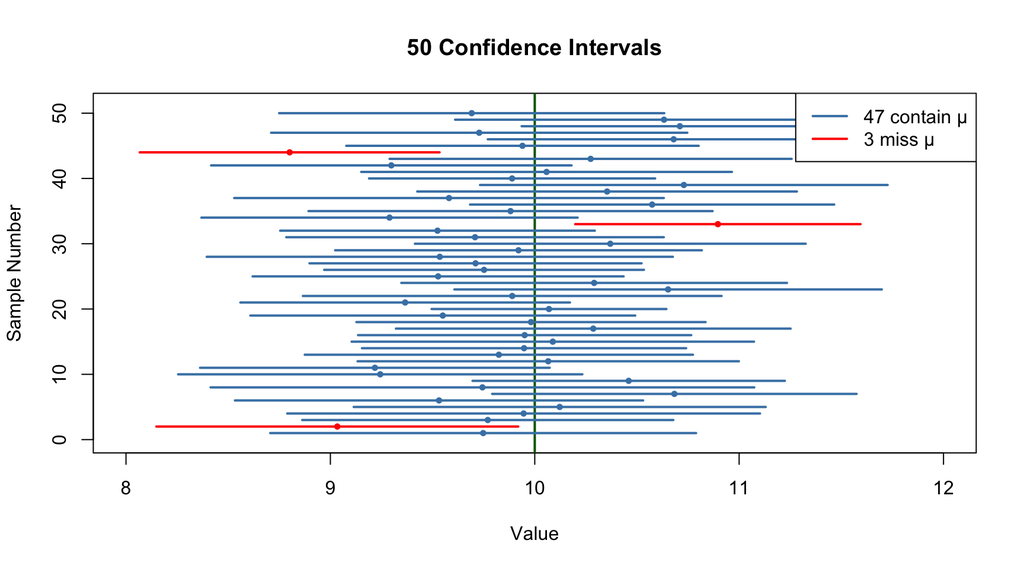

Figure 6: 95% of CIs from repeated sampling contain the true mean (μ = 10)

```r
true_mean <- 10
n_samples <- 50

# Take 50 samples and calculate CIs
results <- t(replicate(n_samples, {
  samp <- rnorm(20, mean = true_mean, sd = 2)
  ci <- t.test(samp)$conf.int
  c(mean = mean(samp), lower = ci[1], upper = ci[2])
}))

# Plot CIs - color red if they miss the true mean
contains_true <- results[, "lower"] <= true_mean & results[, "upper"] >= true_mean
colors <- ifelse(contains_true, "steelblue", "red")

plot(NULL, xlim = c(8, 12), ylim = c(0, n_samples + 1),
     xlab = "Value", ylab = "Sample Number", main = "50 Confidence Intervals")
abline(v = true_mean, col = "darkgreen", lwd = 2)
for(i in 1:n_samples) {
  segments(results[i, "lower"], i, results[i, "upper"], i, col = colors[i], lwd = 2)
  points(results[i, "mean"], i, pch = 19, cex = 0.6, col = colors[i])
}
legend("topright", c(paste(sum(contains_true), "contain μ"),
       paste(sum(!contains_true), "miss μ")), col = c("steelblue", "red"), lwd = 2)
```

- Each horizontal line represents a 95% confidence interval from a different random sample
- Blue intervals contain the true population mean; red intervals miss it
- Approximately 95% of intervals capture the true mean, illustrating the frequentist interpretation of confidence
- This demonstrates that “95% confidence” refers to the long-run coverage rate, not the probability that any single interval contains the parameter

```r
# Try changing the confidence level to 99% and see how interval width changes
true_mean <- 10
n_samples <- 50

results_99 <- t(replicate(n_samples, {
  samp <- rnorm(20, mean = true_mean, sd = 2)
  ci <- t.test(samp, conf.level = 0.99)$conf.int
  c(mean = mean(samp), lower = ci[1], upper = ci[2])
}))

# How does the coverage change? Are the intervals wider or narrower?
contains_true <- results_99[, "lower"] <= true_mean & results_99[, "upper"] >= true_mean
cat("Coverage at 99%:", sum(contains_true), "/", n_samples)

# Also try: What happens with smaller samples (n=5) vs larger (n=100)?
```

## Coefficient of Variation

To compare standard deviations across populations with different means:

- Equation
- LaTeX
- Interpretation

$$CV = \frac{s}{\bar{x}} \times 100\%$$

```
CV = \frac{s}{\bar{x}} \times 100\%
```

- The CV expresses the standard deviation as a percentage of the mean
- This allows comparison of variability between populations with very different means
- A higher CV indicates greater relative variability